# Estudios de Informática, Multimedia y Telecomunicaciones

# PRA2_Grupal_Cortez_Guzman

Bryan Cortéz, Cesar Guzman

28/12/2021

# 1 Importación de Datasets

A continuación procedemos a leer los archivos del directorio raíz del programa.

```r
library(dplyr)


ds1.covid<-read.csv("./Covid-19-Global-Dataset.csv",header=T,sep=",")
ds2.covid<-read.csv("./COVID-19-World-Vaccination-Progress.csv",header=T,sep=",")
```

# 2 Descripción de los Datos

A continuación procedemos a mostrar la descripción de los datos.

Comenzamos por el primer dataset.

```r
str(ds1.covid)
```

```
## 'data.frame':    145221 obs. of  7 variables:
##  $ date                   : chr  "2020-2-15" "2020-2-16" "2020-2-17" "2020-2-18" ...
##  $ country                : chr  "Afghanistan" "Afghanistan" "Afghanistan" "Afghanistan" ...
##  $ cumulative_total_cases : num  0 0 0 0 0 0 0 0 0 1 ...
##  $ daily_new_cases        : num  NA NA NA NA NA NA NA NA NA NA ...
##  $ active_cases           : num  0 0 0 0 0 0 0 0 0 1 ...
##  $ cumulative_total_deaths: num  0 0 0 0 0 0 0 0 0 0 ...
##  $ daily_new_deaths       : num  NA NA NA NA NA NA NA NA NA NA ...
```

Proseguimos viendo el segundo dataset.

```r
str(ds2.covid)
```

```
## 'data.frame':    63401 obs. of  15 variables:
##  $ country                            : chr  "Afghanistan" "Afghanistan" "Afghanistan" "Afghanistan" ...
##  $ iso_code                           : chr  "AFG" "AFG" "AFG" "AFG" ...
##  $ date                               : chr  "2021-02-22" "2021-02-23" "2021-02-24" "2021-02-25" ...
##  $ total_vaccinations                 : num  0 NA NA NA NA NA 8200 NA NA NA ...
##  $ people_vaccinated                  : num  0 NA NA NA NA NA 8200 NA NA NA ...
##  $ people_fully_vaccinated            : num  NA NA NA NA NA NA NA NA NA NA ...
##  $ daily_vaccinations_raw             : num  NA NA NA NA NA NA NA NA NA NA ...
##  $ daily_vaccinations                 : num  NA 1367 1367 1367 1367 ...
##  $ total_vaccinations_per_hundred     : num  0 NA NA NA NA NA 0.02 NA NA NA ...
##  $ people_vaccinated_per_hundred      : num  0 NA NA NA NA NA 0.02 NA NA NA ...
##  $ people_fully_vaccinated_per_hundred: num  NA NA NA NA NA NA NA NA NA NA ...
##  $ daily_vaccinations_per_million     : num  NA 34 34 34 34 34 34 40 45 50 ...
##  $ vaccines                           : chr  "Johnson&Johnson, Oxford/AstraZeneca, Pfizer/BioNTech, Sinopharm/Beijing" "Johnson&Johnson, Oxford/AstraZeneca, Pfizer/BioNTech, Sinopharm/Beijing" "Johnson&Johnson, Oxford/AstraZeneca, Pfizer/BioNTech, Sinopharm/Beijing" "Johnson&Johnson, Oxford/Astra…
##  $ source_name                        : chr  "World Health Organization" "World Health Organization" "World Health Organization" "World Health Organization" ...
##  $ source_website                     : chr  "https://reliefweb.int/sites/reliefweb.int/files/resources/weekly-epidemiological-bulletin_w47.pdf" "https://reliefweb.int/sites/reliefweb.int/files/resources/weekly-epidemiological-bulletin_w47.pdf" "https://reliefweb.int/sites/reliefweb.int/files/res…
```

```r
suppressWarnings(unique(as.integer(format(ds1.covid$date, format="%Y"))))
```

```
## [1] NA
```

```r
suppressWarnings(unique(as.integer(format(ds2.covid$date, format="%Y"))))
```

```
## [1] NA
```

# 3 Integración de los Datos

A continuación procedemos a mostrar la integración de los datos.

## 3.1 Conversión de los Datos

```r
ds1.covid$date=as.Date(ds1.covid$date)
ds1.covid$year=as.integer(format(ds1.covid$date, format="%Y"))
ds1.covid$month=as.integer(format(ds1.covid$date, format="%m"))
```

Procedemos a filtrar los datos correspondiente al último día de cada mes de un año en específico.

```r
ds1.covid.modf = data.frame(ds1.covid %>%
                  group_by(country,strftime(date, "%Y-%m")) %>%
                  filter(date == max(date)))
```

Continuamos con la selección y reordenación de las columnas.

```r
ds1.covid.modf=data.frame(ds1.covid.modf[8:9],ds1.covid.modf[2:7])
```

Repetimos el procedimiento con el segundo dataset.

```r
ds2.covid$date=as.Date(ds2.covid$date)
ds2.covid$year=as.integer(format(ds2.covid$date, format="%Y"))
ds2.covid$month=as.integer(format(ds2.covid$date, format="%m"))
```

Continuamos con la selección y reordenación de las columnas.

```r
ds2.covid<-ds2.covid %>% select(c(1,3:12,16,17,13))
```

Procedemos a filtrar los datos correspondiente al último día de cada mes de un año en específico y de un país en específico.

```r
ds2.covid.modf = data.frame(ds2.covid %>%
                  group_by(country,strftime(date, "%Y-%m")) %>%
                  filter(date == max(date)))
```

Continuamos con la selección y reordenación de las columnas.

```r
ds2.covid.modf=data.frame(ds2.covid.modf[12:13],ds2.covid.modf[1],ds2.covid.modf[3:11],ds2.covid.modf[14])
```

## 3.2 Integración de los Datos

Continuamos con la integración de los 2 conjuntos de datos.

```r
ds.covid.cst <- merge(ds1.covid.modf, ds2.covid.modf,by=c("country","year","month"))
```

# 4 Limpieza de los Datos

## 4.1 Visualización de datos vacíos

A continuación procedemos a Obtener cantidad de ceros por columna del conjunto de datos.

```r
cant.ceros <- data.frame(colSums(ds.covid.cst[4:17] == 0, na.rm = T))
names(cant.ceros) <- c("cantidad")
```

Vemos la cantidad total de ceros.

```r
sum(cant.ceros$cantidad)
```

```
## [1] 1068
```

Obtenemos la cantidad de valores NA

```r
cant.na <- data.frame(colSums(is.na(ds.covid.cst[4:17])))
names(cant.na) <- c("cantidad")
```

Vemos la cantidad total de valores NA.

```r
sum(cant.na$cantidad)
```

```
## [1] 6334
```

## 4.2 Remplazo de los valores vacíos

Procedemos a reemplazar los valores vacíos por cero.

```r
ds.covid.cst[is.na(ds.covid.cst)] <- 0
```

## 4.3 Guardado del conjunto de datos

Finalmente vemos como queda nuestro nuevo dataset antes de guardarlo.

```r
str(ds.covid.cst)
```

```
## 'data.frame':    1958 obs. of  18 variables:
##  $ country                            : chr  "Afghanistan" "Afghanistan" "Afghanistan" "Afghanistan" ...
##  $ year                               : int  2021 2021 2021 2021 2021 2021 2021 2021 2021 2021 ...
##  $ month                              : int  10 11 2 3 4 5 6 7 8 9 ...
##  $ cumulative_total_cases             : num  156250 157303 55733 56517 59942 ...
##  $ daily_new_cases                    : num  40 42 19 63 197 ...
##  $ active_cases                       : num  20325 9446 3956 2478 4105 ...
##  $ cumulative_total_deaths            : num  7280 7308 2444 2489 2631 ...
##  $ daily_new_deaths                   : num  8 0 1 5 6 30 91 29 5 2 ...
##  $ total_vaccinations                 : num  0 5228706 8200 0 0 ...
##  $ people_vaccinated                  : num  0 4397449 8200 0 0 ...
##  $ people_fully_vaccinated            : num  0 3566192 0 0 0 ...
##  $ daily_vaccinations_raw             : num  0 0 0 0 0 0 0 0 0 0 ...
##  $ daily_vaccinations                 : num  36635 15991 1367 3000 13921 ...
##  $ total_vaccinations_per_hundred     : num  0 13.13 0.02 0 0 ...
##  $ people_vaccinated_per_hundred      : num  0 11.04 0.02 0 0 ...
##  $ people_fully_vaccinated_per_hundred: num  0 8.95 0 0 0 0 0.47 0 0 0 ...
##  $ daily_vaccinations_per_million     : num  920 401 34 75 349 ...
##  $ vaccines                           : chr  "Johnson&Johnson, Oxford/AstraZeneca, Pfizer/BioNTech, Sinopharm/Beijing" "Johnson&Johnson, Oxford/AstraZeneca, Pfizer/BioNTech, Sinopharm/Beijing" "Johnson&Johnson, Oxford/AstraZeneca, Pfizer/BioNTech, Sinopharm/Beijing" "Johnson&Johnson, Oxford/Astra…
```

Procedemos a guardar el conjunto de datos.

```r
write.csv(x=ds.covid.cst, file="dataset_covid.csv")
```

# 5 Análisis de datos

Para temas prácticos, vamos a enfocarnos en analizar cuatro países con los cuales haremos las comparativas. Para ellos escogimos a Ecuador, porque es el país de los dos miembros que integran este equipo; España, que es el único país desarrollado de habla hispana y el cual sirve de referencia para las comparativas respecto a los países de Latinoamérica; Alemania, por ser el país más rico de la Unión Europea y uno de los que aparentemente sobrellevaron al inicio la pandemia y por último, Estados Unidos, que es el país más rico del mundo, pero que tuvo bastantes dificultades sobrellevando la pandemia, al menos al inicio. Por tanto, vamos a proceder analizando que tal lo ha hecho nuestro país frente a las grandes potencias mundiales.

```r
ds.covid.info_ec <- ds.covid.cst[ds.covid.cst$country == "Ecuador",]
ds.covid.info_es <- ds.covid.cst[ds.covid.cst$country == "Spain",]
ds.covid.info_de <- ds.covid.cst[ds.covid.cst$country == "Germany",]
ds.covid.info_us <- ds.covid.cst[ds.covid.cst$country == "United States",]


filas_ec=dim(ds.covid.info_ec)[1]
filas_es=dim(ds.covid.info_es)[1]
filas_de=dim(ds.covid.info_de)[1]
filas_us=dim(ds.covid.info_us)[1]
filas_total=dim(ds.covid.cst)[1]
```

## 5.1 Comprobación de la normalidad y homogeneidad de la varianza

Vamos a proceder comprobando los valores que toman las variables cuantitativas provienen de una población distribuida normalmente, para ello utilizaremos la prueba de normalidad de Anderson-Darling.

Para ello, vamos a comprobar cada variable si obtiene un p-valor superior al nivel de significación prefijado α = 0, 05. Si esto se cumple, entonces se considera que variable en cuestión sigue una distribución normal.

```r
library(nortest)


alpha = 0.05
col.names = colnames(ds.covid.cst)
for (i in 1:ncol(ds.covid.cst)) {
  if (i == 1) cat("Variables que no siguen una distribución normal:\n")
  if (is.integer(ds.covid.cst[,i]) | is.numeric(ds.covid.cst[,i])) {
    p_val = ad.test(ds.covid.cst[,i])$p.value
    if (p_val < alpha) {
      cat(col.names[i])

      if (i < ncol(ds.covid.cst) - 1) cat(", ")
      if (i %% 3 == 0) cat("\n")
    }
  }
}
```

```
## Variables que no siguen una distribución normal:
## year, month,
## cumulative_total_cases, daily_new_cases, active_cases,
## cumulative_total_deaths, daily_new_deaths, total_vaccinations,
## people_vaccinated, people_fully_vaccinated, daily_vaccinations_raw,
## daily_vaccinations, total_vaccinations_per_hundred, people_vaccinated_per_hundred,
## people_fully_vaccinated_per_hundred, daily_vaccinations_per_million
```

Continuamos con la homogeneidad de varianzas mediante la aplicación de un test de Fligner-Killeen. Para ello, estudiaremos esta homogeneidad en cuanto a los grupos conformados por las casos acumulados y las muertes acumuladas. En el siguiente test, la hipótesis nula consiste en que ambas varianzas son iguales.

```r
fligner.test(cumulative_total_cases ~ cumulative_total_deaths, data = ds.covid.cst)
```

```
##
##  Fligner-Killeen test of homogeneity of variances
##
## data:  cumulative_total_cases by cumulative_total_deaths
## Fligner-Killeen:med chi-squared = 1746.2, df = 1524, p-value = 5.77e-05
```

Como podemos ver, el valor obtenido de p-value es inferior al aceptado de 0.05, desestimamos que la hipótesis de que las varianzas de ambas muestras sean homogéneas.

## 5.2 Pruebas Estadísticas

```r
if(!require(ggplot2)){
    install.packages('ggplot2', repos='http://cran.us.r-project.org')
    library(ggplot2)
}

if(!require(ggpubr)){
    install.packages('ggpubr', repos='http://cran.us.r-project.org')
    library(ggpubr)
}

if(!require(grid)){
    install.packages('grid', repos='http://cran.us.r-project.org')
    library(grid)
}

if(!require(gridExtra)){
    install.packages('gridExtra', repos='http://cran.us.r-project.org')
    library(gridExtra)
}

if(!require(C50)){
    install.packages('C50', repos='http://cran.us.r-project.org')
    library(C50)
}
```

Primero, comenzaremos con un análisis visual de los datos del último año. Viendo de la distribución de casos diarios, casos acumulados, decesos y vacunación en el tiempo en Ecuador.

Como se puede visualizar en la primera gráfica, vemos que a partir de mayo de 2021, cuando se posicionó el nuevo gobierno, comenzaron a descender los casos nuevos casos, gracias a la implementación del nuevo plan de vacunación. Lo mismo se puede ver en las otras gráficas que se marca una diferencia a partir de mayo en las tendencias, empezando desde abajo hasta llegar al punto de la nueva ola formada por las variantes Delta y Omicron.

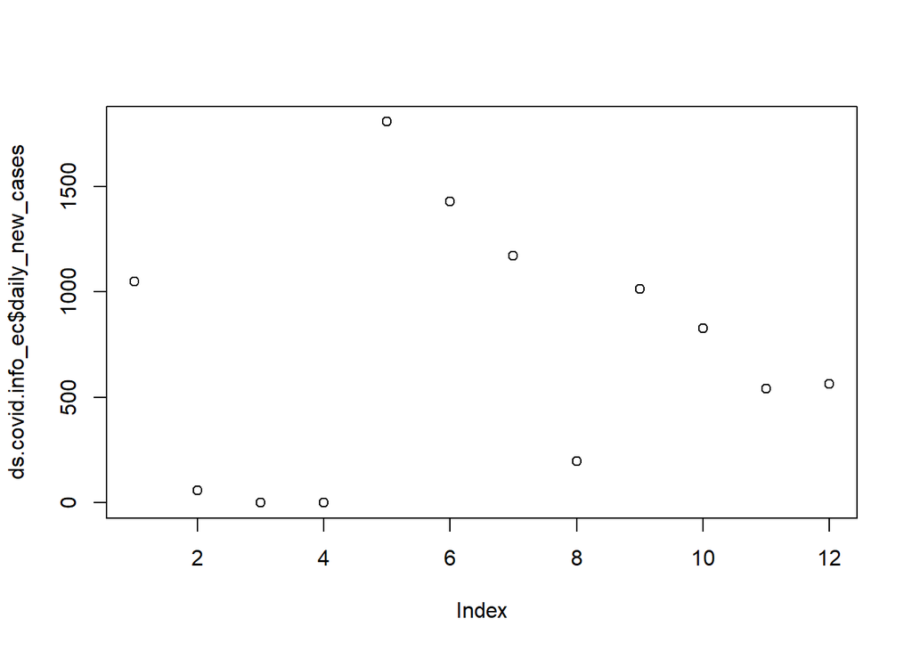

```r
plot(ds.covid.info_ec$daily_new_cases)
```

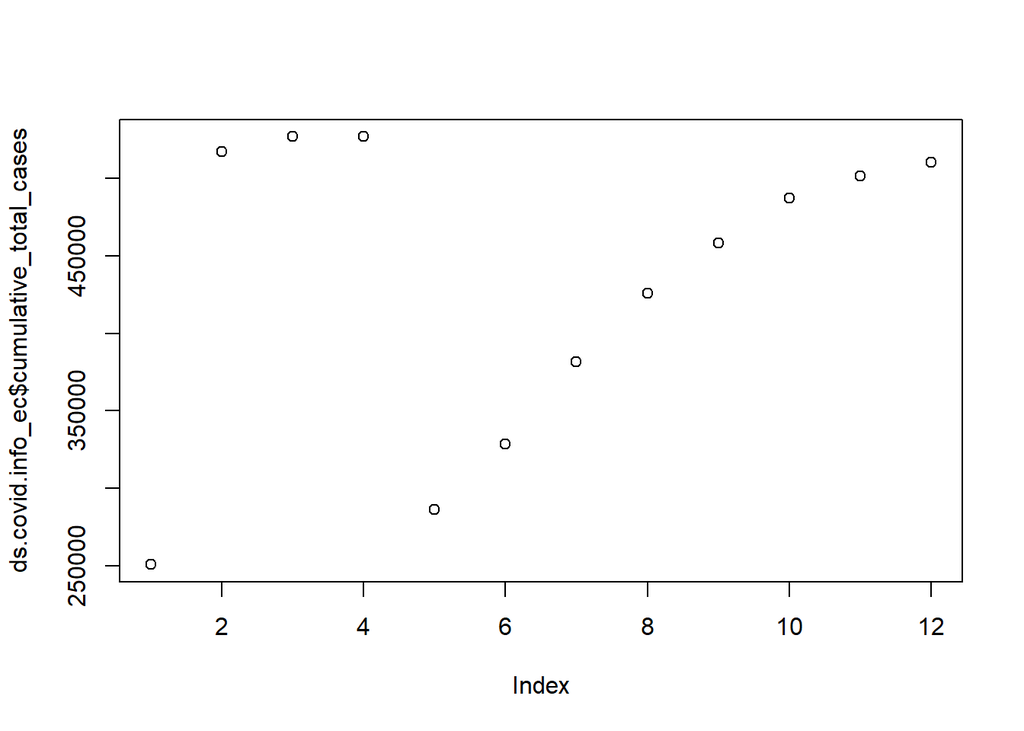

```r
plot(ds.covid.info_ec$cumulative_total_cases)
```

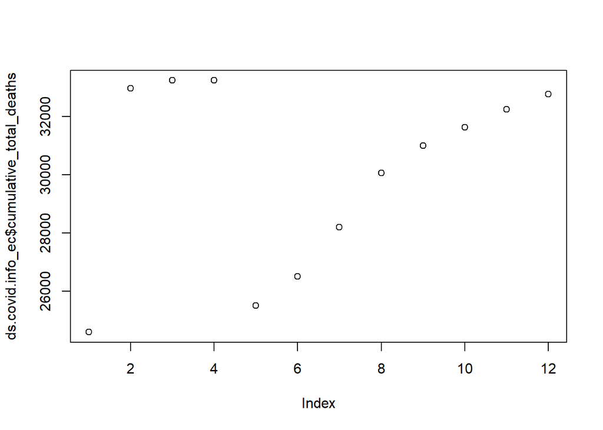

```r
plot(ds.covid.info_ec$cumulative_total_deaths)
```

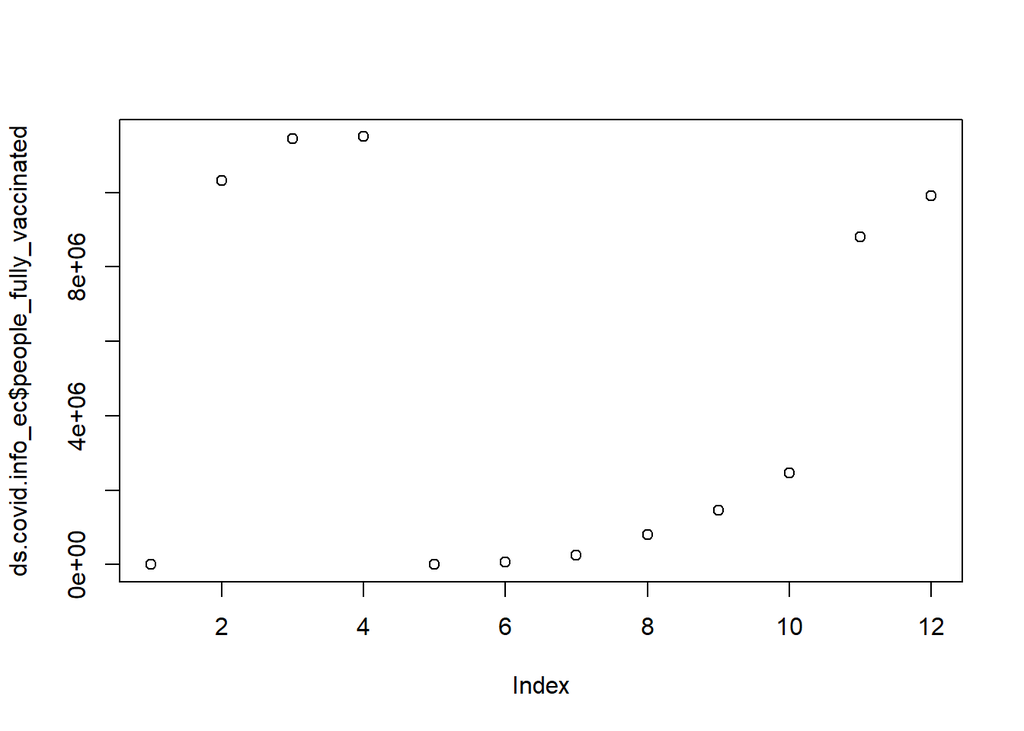

```r
plot(ds.covid.info_ec$people_fully_vaccinated)
```

Continuamos viendo la distribución de casos diarios, casos acumulados, decesos y vacunación en el tiempo en España.

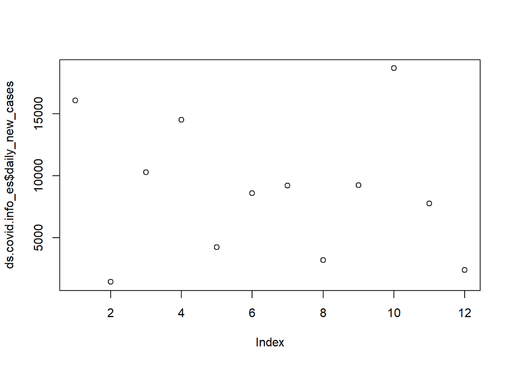

```r
plot(ds.covid.info_es$daily_new_cases)
```

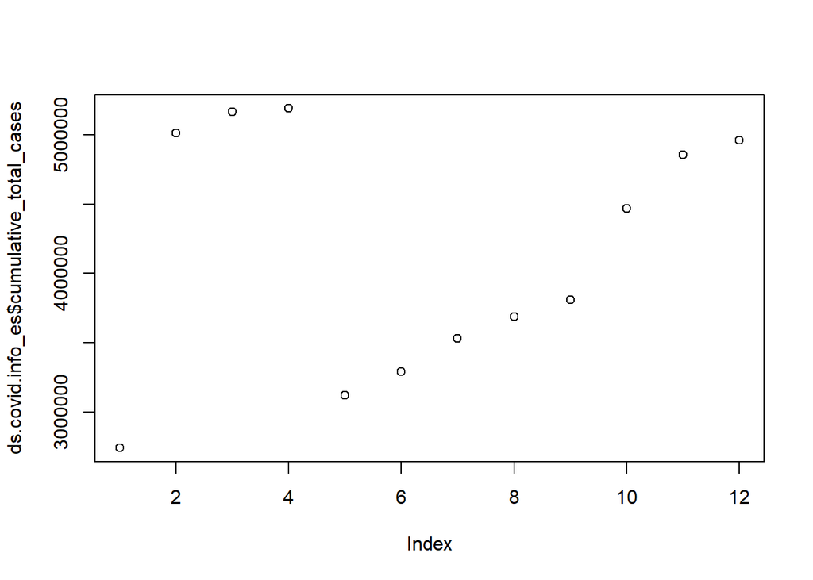

```r
plot(ds.covid.info_es$cumulative_total_cases)
```

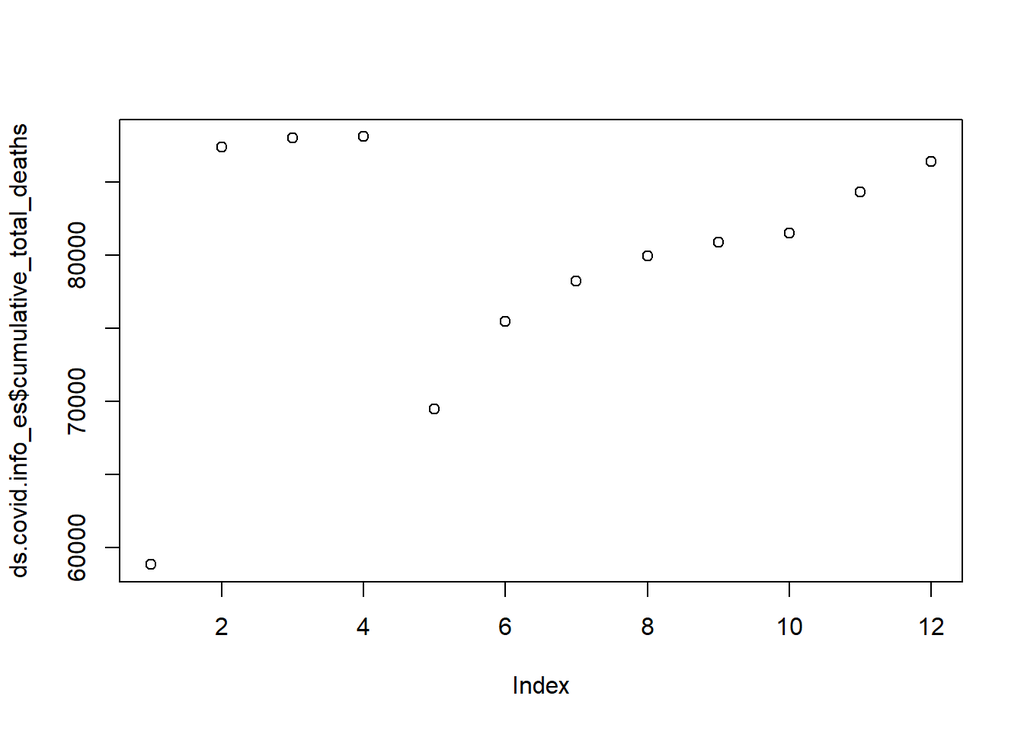

```r
plot(ds.covid.info_es$cumulative_total_deaths)
```

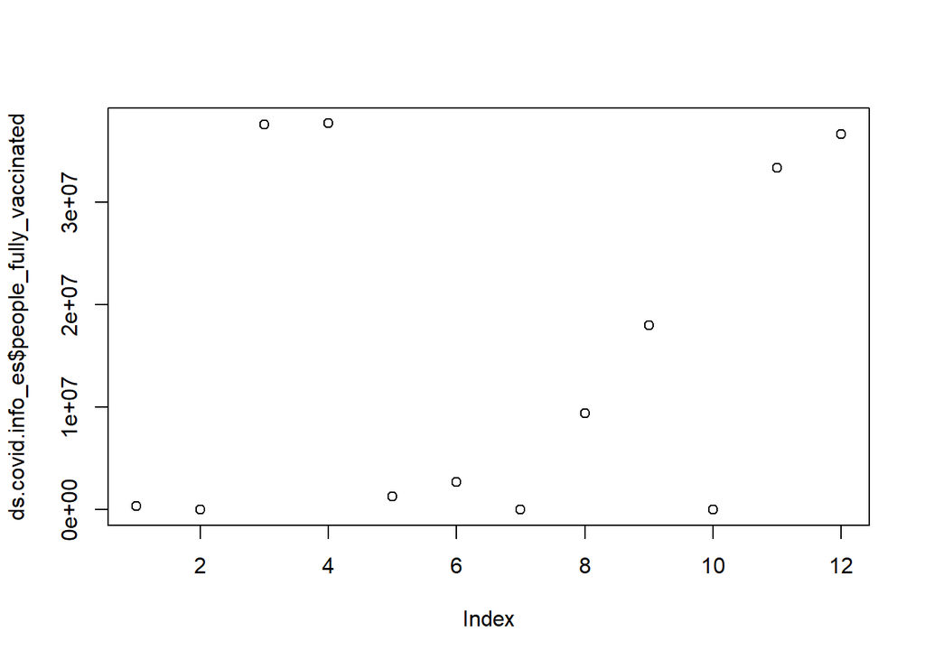

```r
plot(ds.covid.info_es$people_fully_vaccinated)
```

Continuamos viendo la distribución de casos diarios, casos acumulados, decesos y vacunación en el tiempo en Alemania.

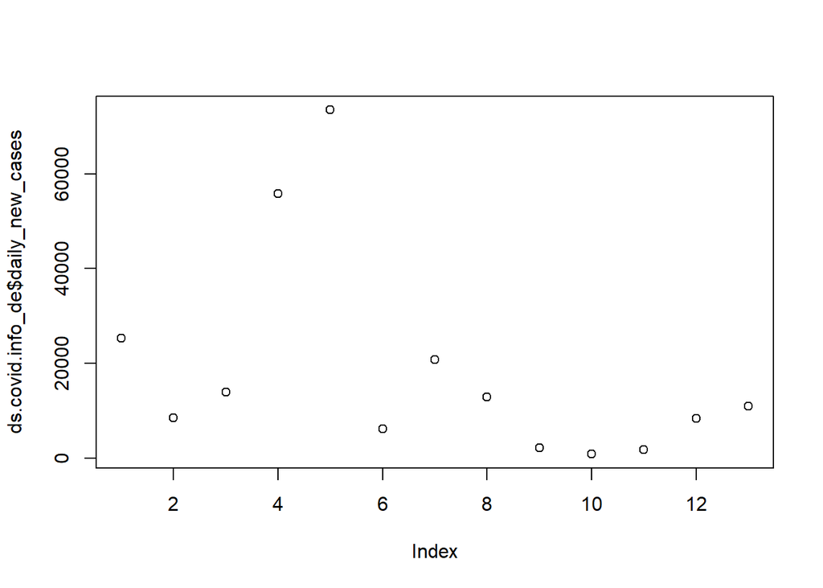

```r
plot(ds.covid.info_de$daily_new_cases)
```

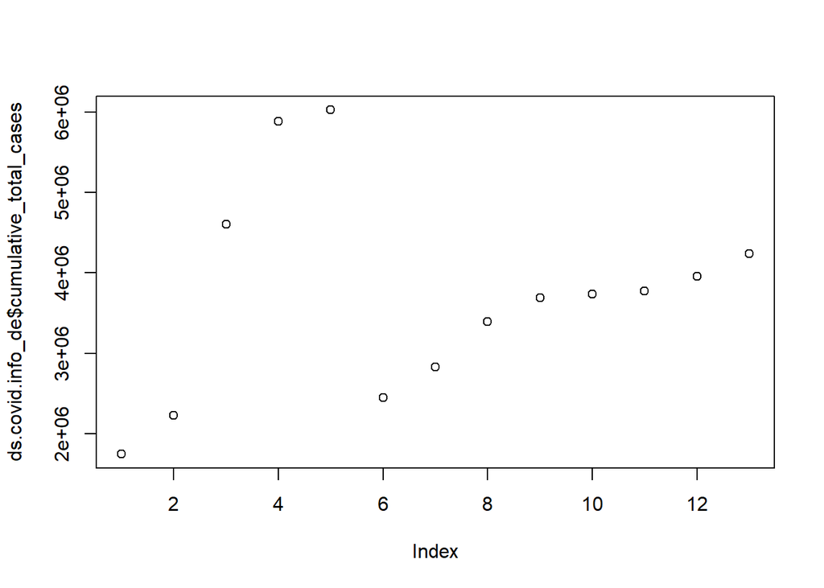

```r
plot(ds.covid.info_de$cumulative_total_cases)
```

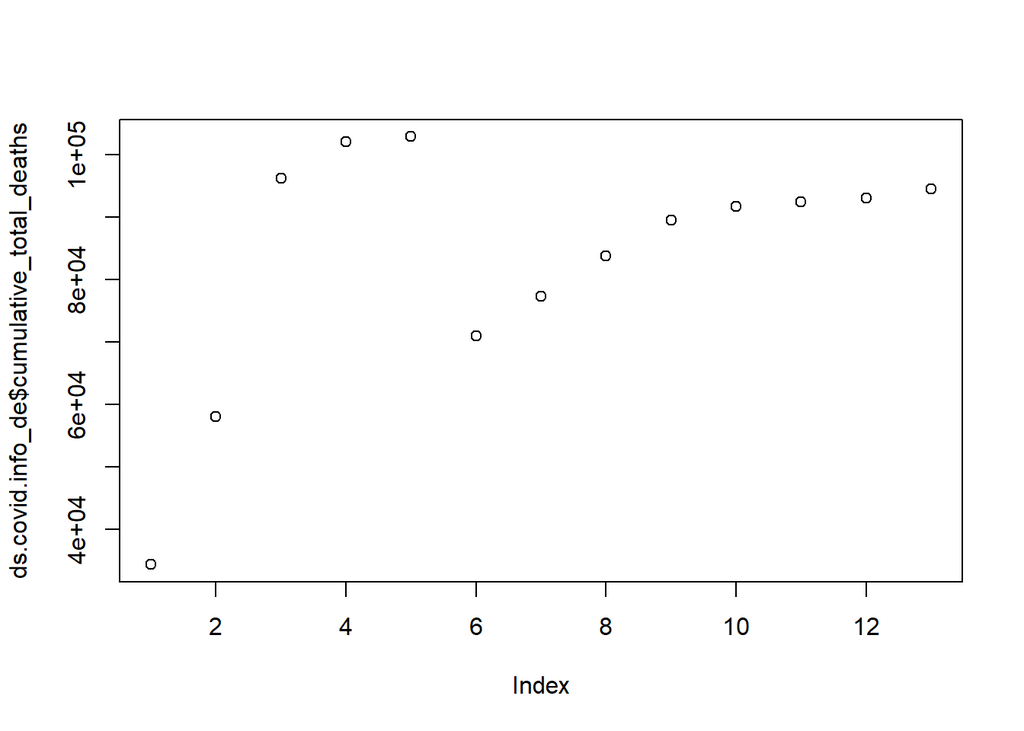

```r
plot(ds.covid.info_de$cumulative_total_deaths)
```

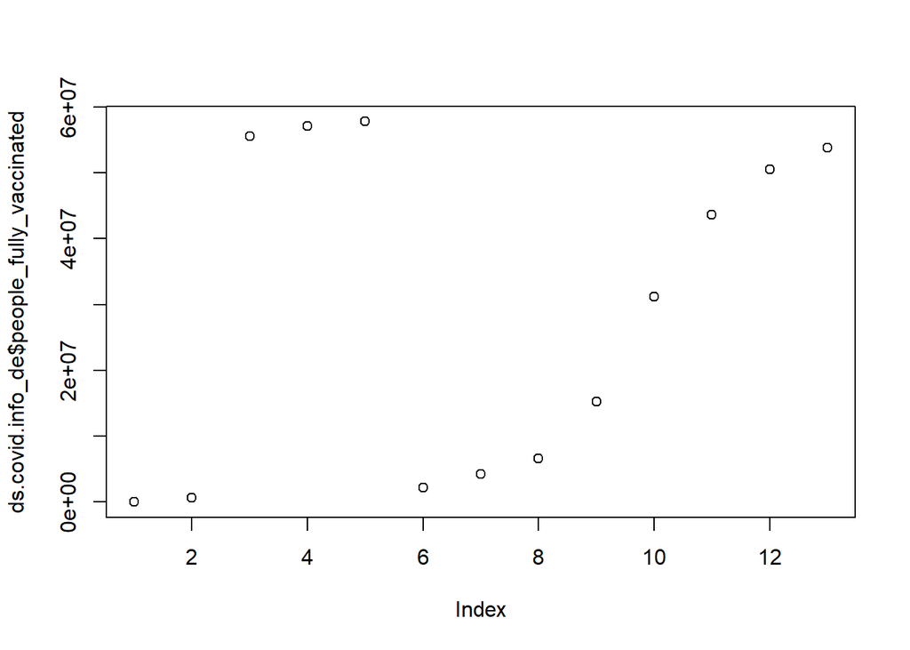

```r
plot(ds.covid.info_de$people_fully_vaccinated)
```

Continuamos viendo la distribución de casos diarios, casos acumulados, decesos y vacunación en el tiempo en Estados Unidos.

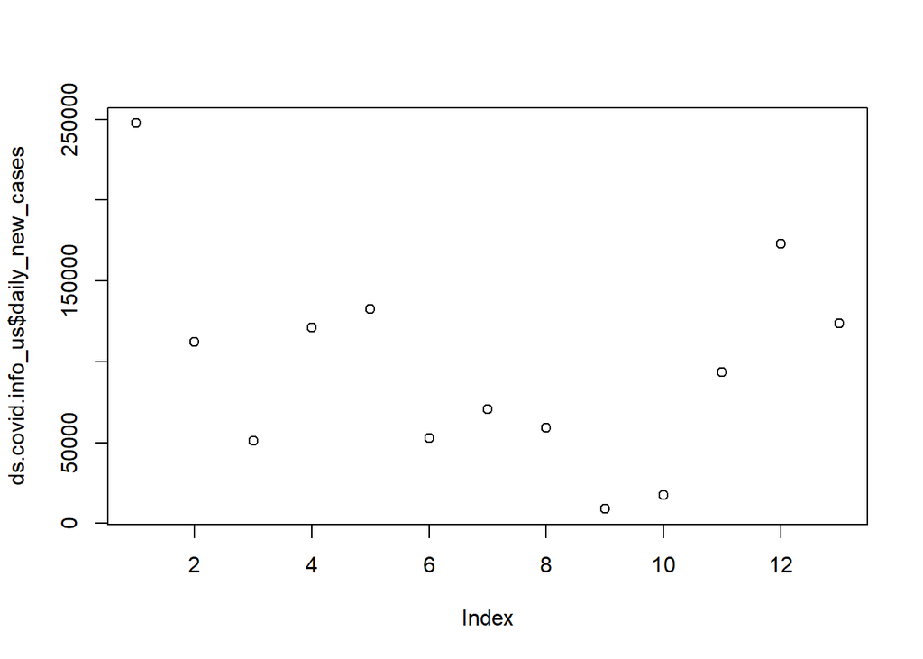

```r
plot(ds.covid.info_us$daily_new_cases)
```

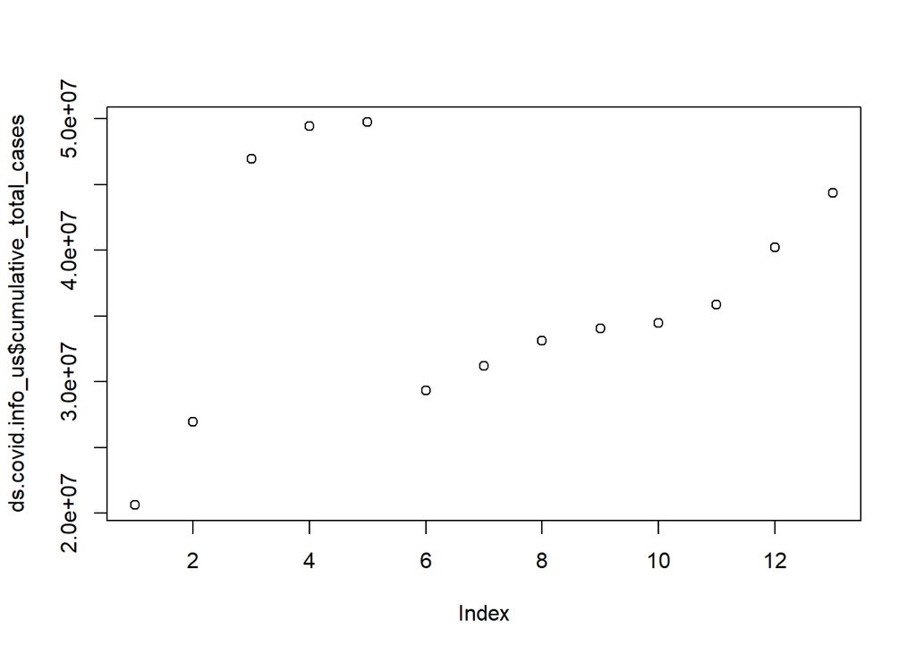

```r
plot(ds.covid.info_us$cumulative_total_cases)
```

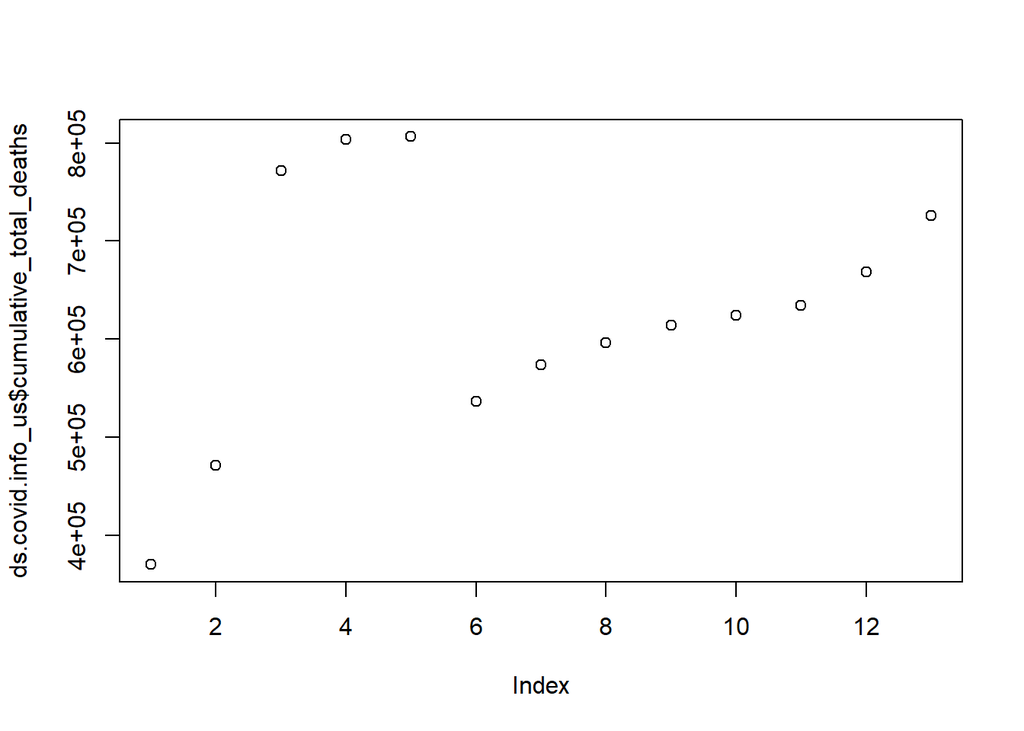

```r
plot(ds.covid.info_us$cumulative_total_deaths)
```

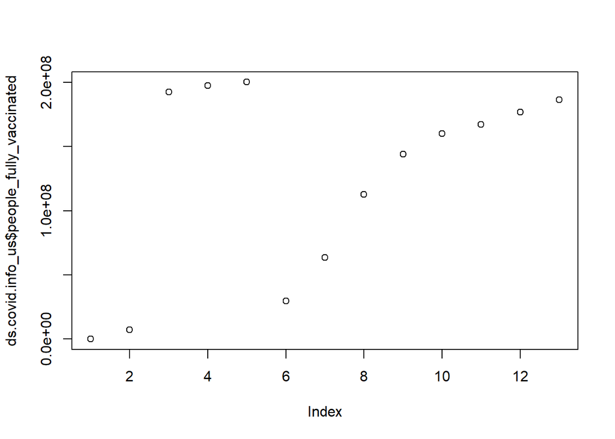

```r
plot(ds.covid.info_us$people_fully_vaccinated)
```

### 5.2.1 Correlación de variables

Procedemos a realizar un análisis de correlación entre todas las variables para determinar cuáles de ellas ejercen una mayor influencia sobre el total de muertes acumuladas. Para lo cual usaremos el método de Spearman, puesto que hemos visto que tenemos datos que no siguen una distribución normal, por lo que no nos sirve el de Pearson. Adicionalmente cada coeficiente de correlación también muestra el p-valor asociado, para dar más información.

```r
corr_matrix <- matrix(nc = 2, nr = 0)
colnames(corr_matrix) <- c("estimate", "p-value")

for (i in 1:(ncol(ds.covid.cst) - 1)) {
  if (is.integer(ds.covid.cst[,i]) | is.numeric(ds.covid.cst[,i])) {
    spearman_test = cor.test(ds.covid.cst[,i],
                             ds.covid.cst[,7],
                             method = "spearman")
    corr_coef = spearman_test$estimate
    p_val = spearman_test$p.value

    pair = matrix(ncol = 2, nrow = 1)
    pair[1][1] = corr_coef
    pair[2][1] = p_val
    corr_matrix <- rbind(corr_matrix, pair)
    rownames(corr_matrix)[nrow(corr_matrix)] <- colnames(ds.covid.cst)[i]
  }
}

print(corr_matrix)
```

```
##                                        estimate       p-value
## year                                -0.03329326  1.408399e-01
## month                                0.07477283  9.290738e-04
## cumulative_total_cases               0.95792371  0.000000e+00
## daily_new_cases                      0.78042855  0.000000e+00
## active_cases                         0.79028569  0.000000e+00
## cumulative_total_deaths              1.00000000  0.000000e+00
## daily_new_deaths                     0.79687080  0.000000e+00
## total_vaccinations                   0.55973068 7.359973e-162
## people_vaccinated                    0.52898636 1.275459e-141
## people_fully_vaccinated              0.53093772 7.629395e-143
## daily_vaccinations_raw               0.53223948 1.153569e-143
## daily_vaccinations                   0.76062117  0.000000e+00
## total_vaccinations_per_hundred       0.32997725  5.903873e-51
## people_vaccinated_per_hundred        0.31117394  3.192217e-45
## people_fully_vaccinated_per_hundred  0.33617337  6.183155e-53
## daily_vaccinations_per_million       0.16762742  8.295854e-14
```

Como podemos ver las variables más correlacionadas con el total de muertes acumuladas en función de su proximidad con los valores -1 y +1 son el total de casos acumulados, los casos activos, los nuevos casos diarios, las muertes diarias y las vacunaciones diarias

### 5.2.2 Prueba de Contraste

La segunda prueba estadística que vamos a realizar, será una prueba de contraste de hipótesis, la cual plantea que “La proporción de muertes por Covid-19 es menor en los países desarrollados?” Para ello, usaremos la comparativa de Ecuador, con España, Alemania y Estados Unidos, que tienen un PIB per cápita entre 6, 10 y 12 veces mayor respectivamente, por lo que en teoría deberían tener un mejor sistema de salud.

```r
t.test(ds.covid.info_ec$cumulative_total_deaths, ds.covid.info_es$cumulative_total_deaths, alternative = "less")
```

```
##
##  Welch Two Sample t-test
##
## data:  ds.covid.info_ec$cumulative_total_deaths and ds.covid.info_es$cumulative_total_deaths
## t = -18.602, df = 13.889, p-value = 1.632e-11
## alternative hypothesis: true difference in means is less than 0
## 95 percent confidence interval:
##       -Inf -45009.42
## sample estimates:
## mean of x mean of y
##  30167.58  79887.25
```

```r
t.test(ds.covid.info_ec$cumulative_total_deaths, ds.covid.info_de$cumulative_total_deaths, alternative = "less")
```

```
##
##  Welch Two Sample t-test
##
## data:  ds.covid.info_ec$cumulative_total_deaths and ds.covid.info_de$cumulative_total_deaths
## t = -9.7556, df = 12.691, p-value = 1.467e-07
## alternative hypothesis: true difference in means is less than 0
## 95 percent confidence interval:
##       -Inf -43732.88
## sample estimates:
## mean of x mean of y
##  30167.58  83622.15
```

```r
t.test(ds.covid.info_ec$cumulative_total_deaths, ds.covid.info_us$cumulative_total_deaths, alternative = "less")
```

```
##
##  Welch Two Sample t-test
##
## data:  ds.covid.info_ec$cumulative_total_deaths and ds.covid.info_us$cumulative_total_deaths
## t = -16.837, df = 12.016, p-value = 5.058e-10
## alternative hypothesis: true difference in means is less than 0
## 95 percent confidence interval:
##       -Inf -536844.7
## sample estimates:
## mean of x mean of y
##  30167.58 630561.85
```

Si tomamos un α=0.05, entonces vemos que nuestrop-value en todos los casos es menor que el valor de significación fijado. Por tanto vemos que se cumple lo propuesto en la hipótesis.

Aunque si comparamos la proporción de las muertes acumuladas con respecto a la población de cada país, vemos que únicamente Alemania, es el único que realmente tiene una proporción baja de muertes, ya que los otros países sobrepasan el 2%, por lo que podemos decir que no basta la riqueza del país, sino también la gestión y la cultura de cada país para evitar mayor proporción de decesos.

```r
sum(ds.covid.info_ec$cumulative_total_deaths)
```

```
## [1] 362011
```

```r
sum(ds.covid.info_es$cumulative_total_deaths)
```

```
## [1] 958647
```

```r
sum(ds.covid.info_de$cumulative_total_deaths)
```

```
## [1] 1087088
```

```r
sum(ds.covid.info_us$cumulative_total_deaths)
```

```
## [1] 8197304
```

```r
p_ec <- (sum(ds.covid.info_ec$cumulative_total_deaths) / 17640000) * 100

p_es <- (sum(ds.covid.info_es$cumulative_total_deaths) / 47350000) * 100

p_de <- (sum(ds.covid.info_de$cumulative_total_deaths) / 83240000) * 100

p_us <- (sum(ds.covid.info_us$cumulative_total_deaths) / 329500000) * 100

str(p_ec)
```

```
##  num 2.05
```

```r
str(p_es)
```

```
##  num 2.02
```

```r
str(p_de)
```

```
##  num 1.31
```

```r
str(p_us)
```

```
##  num 2.49
```

### 5.2.3 Regresión Lineal

Con el objetivo de realizar futuras predicciones, se plantea realizar un modelo de regresión lineal utilizando regresores tanto cuantitativos como cualitativos con el que poder realizar predicciones sobre las muertes acumuladas. Por tanto, vamos a proceder creando varios modelos de regresión utilizando las variables que estén más correlacionadas con las muertes acumuladas, como ya lo vimos en apartados anteriores. Una vez planteados los modelos, podremos escoger el mejor utilizando como criterio de mayor coeficiente de determinación (R2).

```r
cumulative_total_deaths = ds.covid.cst$cumulative_total_deaths
cumulative_total_cases = ds.covid.cst$cumulative_total_cases
active_cases = ds.covid.cst$active_cases
daily_new_cases = ds.covid.cst$daily_new_cases
daily_new_deaths = ds.covid.cst$daily_new_deaths
daily_vaccinations = ds.covid.cst$daily_vaccinations
country = ds.covid.cst$country


model1 <- lm(cumulative_total_deaths ~ cumulative_total_cases + active_cases + daily_new_cases + daily_new_deaths + ds.covid.cst$daily_vaccinations  + country, data = ds.covid.cst)

model2 <- lm(cumulative_total_deaths ~ daily_new_cases + daily_new_deaths + daily_vaccinations  + country, data = ds.covid.cst)

model3 <- lm(cumulative_total_deaths ~ cumulative_total_cases + active_cases + country, data = ds.covid.cst)

model4 <- lm(cumulative_total_deaths ~ active_cases + daily_new_cases + daily_vaccinations  + country, data = ds.covid.cst)

model5 <- lm(cumulative_total_deaths ~ cumulative_total_cases + daily_new_cases + daily_vaccinations  + country, data = ds.covid.cst)
```

Una vez planteados los modelos con las diferentes combinaciones de variables, continuamos con la comparativa de los coeficientes R2.

```r
coeficients_table <- matrix(c(1, summary(model1)$r.squared,
                              2, summary(model2)$r.squared,
                              3, summary(model3)$r.squared,
                              4, summary(model4)$r.squared,
                              5, summary(model5)$r.squared),
                              ncol = 2, byrow = TRUE)


colnames(coeficients_table) <- c("Modelo", "R^2")
coeficients_table
```

```
##      Modelo       R^2
## [1,]      1 0.9893315
## [2,]      2 0.9387971
## [3,]      3 0.9891282
## [4,]      4 0.9416355
## [5,]      5 0.9887859
```

# 6 Conclusiones

# 7 Recursos

- Guitart Hormigo, I. (2019). Introducción a la limpieza y análisis de los datos. In L. Subirats Maté, D. O. Pérez Trenard, & M. Calvo González. Barcelona: UOC.
- Guitart Hormigo, I. (2019). Introducción al ciclo de vida de los datos. In L. Subirats Maté, D. O. Pérez Trenard, & M. Calvo González. Barcelona: UOC.